# Digital Communication, Part 2

SOLUTIONS

Updated: Friday, November 30, 2018 @ 10:55:37 AM

```r
# load all packages and datasets here
library(tidyverse)
```

1. In Part 1, you analyzed error rates for a single-channel system and a TRC system. One way to reduce transmission errors in either system would be to improve the initial 1% error rate. How xbarch would reducing the error rate improve the performance of the TRC system? Create a plot that shows error rates from 0% to 1% (in increments of 0.1) on the x-axis versus the corresponding probability that any single TRC block (e.g., 000) is interpreted correctly (y-axis). To what value do we have to reduce the initial error rate in order for the probability of a block being correctly transmitted to be at least 99.99%?

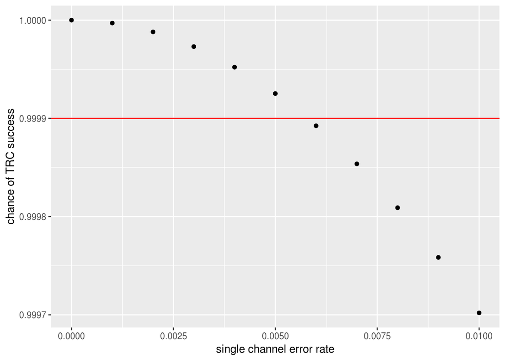

```r
rates <- seq(from = 0, to = 0.01, by = .001)
block <- pbinom(1, 3, 1 - rates, lower.tail = FALSE)
ggplot(NULL, aes(x = rates, y = block)) +
  geom_point() +
  geom_hline(yintercept = 0.9999, color = "red") +
  labs(x = "single channel error rate", y = "chance of TRC success")
```

ANSWER: The single channel error rate needs to be reduced to 0.005 (i.e., cut in half).

2. A 1000 Mbit/s system transmits 10<sup>9</sup> bits per second. Each bit has a 0.03% chance of being incorrectly received when we use TRC and all bits are independent. There are are 86,400 seconds in a day. If X is the number of incorrect bits in a single second, use `rbinom` to simulate the distribution of X for a single day. Assess your simulation results for normality using a density plot, ECDF plot, QQ plot, and goodness of fit test. What do you conclude?

Simulation:

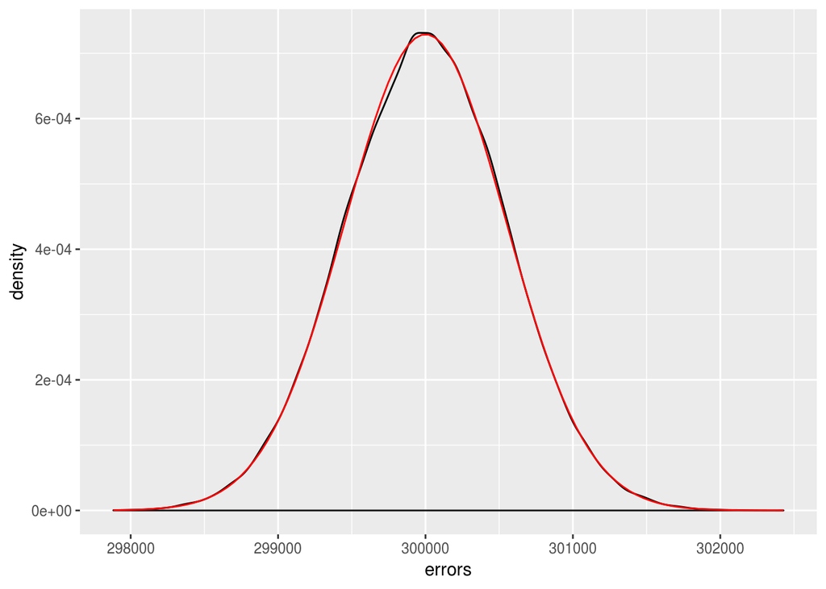

```r
errors <- rbinom(86400, 10^9, 0.0003)
xbar <- mean(errors)
stdv <- sd(errors)

ggplot(NULL, aes(x = errors)) +
  geom_density() +
  stat_function(fun = dnorm,
                args = list(xbar, stdv),
                color = "red")
```

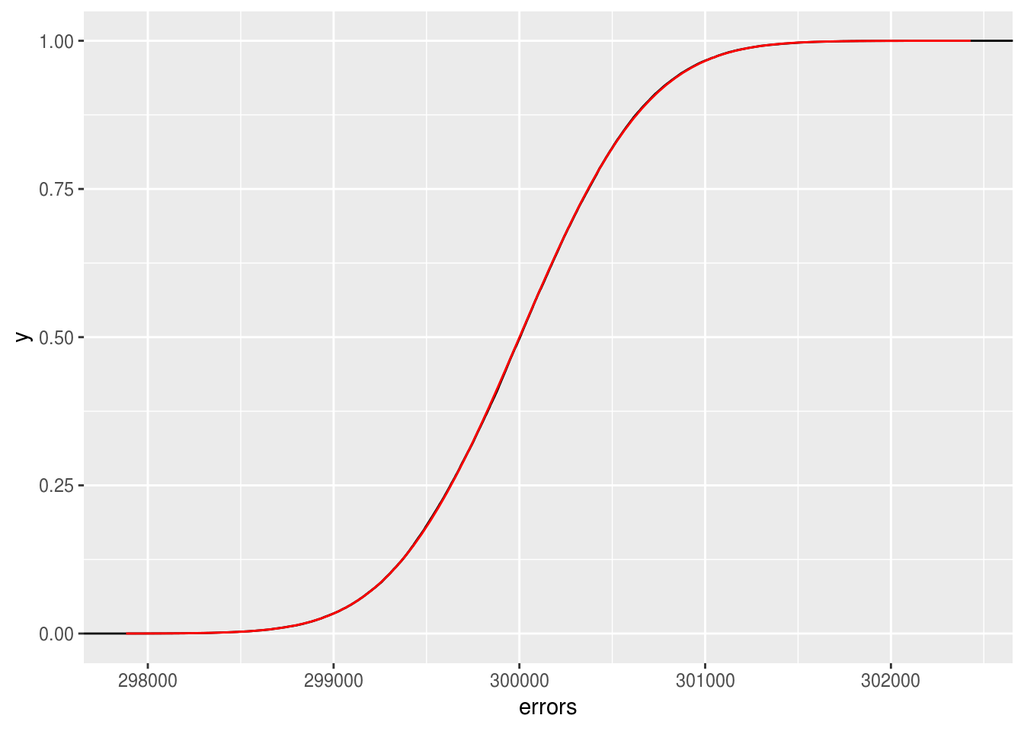

```r
ggplot(NULL, aes(x = errors)) +
  stat_ecdf() +
  stat_function(fun = pnorm,
                args = list(xbar, stdv),
                color = "red")
```

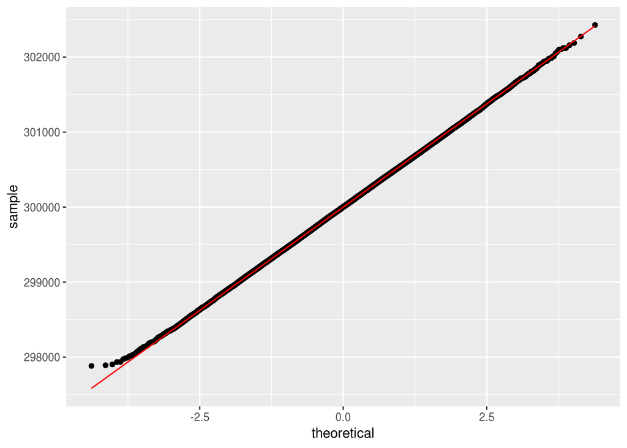

```r
ggplot(NULL, aes(sample = errors)) +
  stat_qq() +
  stat_qq_line(color = "red")
```

Ho: The errors are normally distributed.

Ha: The errors are not normally distributed.

Goodness of Fit Test:

```r
errorscat <- case_when(errors <= xbar - 2*stdv ~ "C1",
                       errors <= xbar - 1*stdv & errors > xbar - 2*stdv ~ "C2",
                       errors <= xbar - 0*stdv & errors > xbar - 1*stdv ~ "C3",
                       errors <= xbar + 1*stdv & errors > xbar - 0*stdv ~ "C4",
                       errors <= xbar + 2*stdv & errors > xbar + 1*stdv ~ "C5",
                       errors >  xbar + 2*stdv ~ "C6")

observed <- table(errorscat)
prop.table(observed)
```

```
errorscat
        C1         C2         C3         C4         C5         C6
0.02271991 0.13747685 0.33766204 0.34385417 0.13589120 0.02239583
```

```r
# Find theoretical probabilities for the intervals.

probs <- c(pnorm(-2),
           pnorm(-1) - pnorm(-2),
           pnorm(0) - pnorm(-1),
           pnorm(1) - pnorm(0),
           pnorm(2) - pnorm(1),
           pnorm(2, lower.tail=F))

chisq.test(observed, p = probs)
```

```
    Chi-squared test for given probabilities

data:  observed
X-squared = 7.0776, df = 5, p-value = 0.2149
```

Conclusions: We fail to reject Ho at the α = 0.05 level and conclude that the errors are normally distributed. This is supported by the plots; in each case the simulated distribution closely follows the theoretical curves.

END PART 2